# Matrices and Images

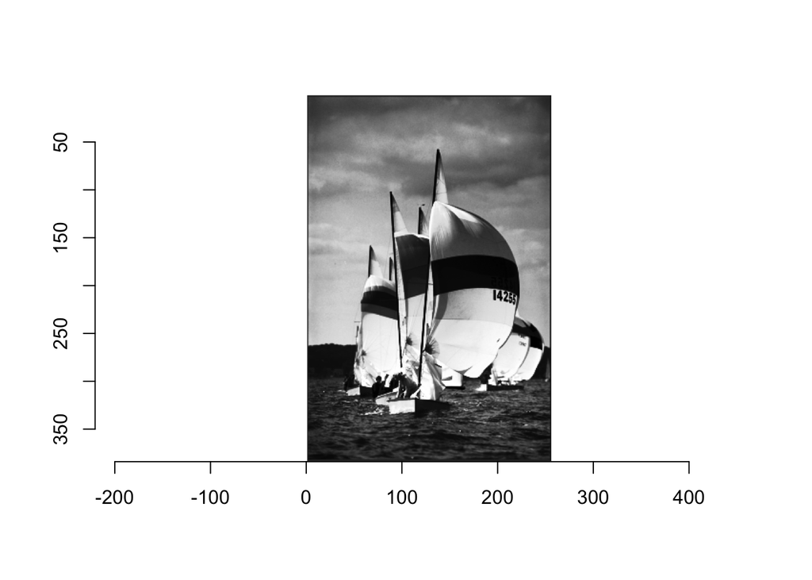

```r
plot(enhanced_grayboats) #plot image
```

Now let’s apply that to the color image (some more fudging here, but you got the basic idea from the grayscale)

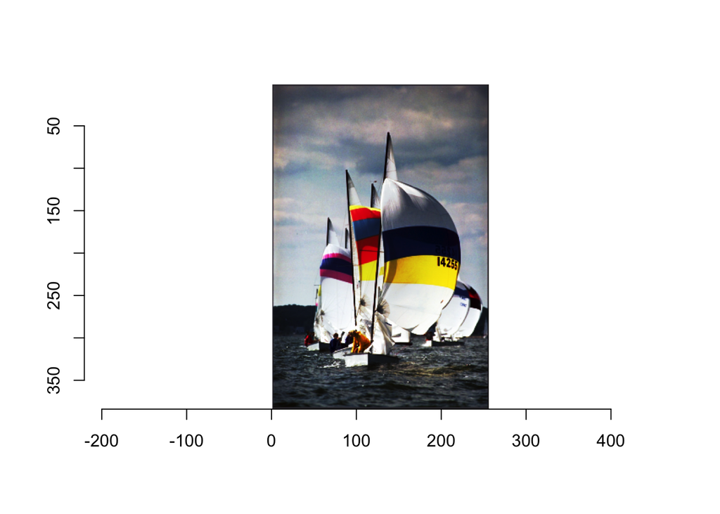

```r
hist.eq <- function(im) as.cimg(ecdf(im)(im),dim=dim(im)) #define new function to make it a bit quicker
cn <- imsplit(boats,"c") #split R, G and B channels
cn.eq <- map_il(cn,hist.eq) #separate normalization on each channel as we did with grayscale
enhanced_image<-imappend(cn.eq,"c") #convert back to color image
plot(enhanced_image) #render new image
```

So you can probably tell that some of the magic you see in photo processing software these days relies on fairly simple math (though a lot of it gets more complicated than this!). But hopefully I’ve explained how you turn images into numbers. Maybe you can even start to think how you can turn numbers into images, as you can in drawing software or CGI for example.